# **💌 U.S. Logistics Performance Dataset ✧₊˚**

## **Fall 2025 Data Science Project**

#### **Group Members:** Lexin Deang, Kirsten Fragante, Safiyah Fatima, Jeremy Menecio, Thomas Schlinke

#### **Contributions:**

- Lexin Deang: Contributed on establishing sound analysis for EDA (Conclusion), worked on providing the Random Forest Regressor model training, testing & analysis, as well as contributed in formatting the final product to ensure consistent results.
- Kirsten Fragante: Worked on the exploratory data analysis section, coming up with the ideas for the three hypothesis tests and writing the code to perform the initial cleanup of the dataset and conduct the tests. Also contributed to EDA analysis and the formatting for the overall presentation of our notebook.
- Safiyah Fatima: Contributed to Overview of Dataset and basic exploration of numerical data + descriptions/documentation for analysis.
- Jeremy Menecio: Worked on the Clustering section which involved use of Feature Engineering, Elbow method, Silhouette score, and visualization to properly describe and interpret results in a logistical context.
- Thomas Schlinke: Worked on the conclusion, analysis of Random Forest Regressor model, the written section introducing machine learning and what we hoped to gain from it, and feature importance analysis.

## **Introduction**

#### **GitHub:** https://github.com/jerrayhan/320FinalProject

#### **Dataset:** [Kaggle - U.S. Logistics Performance Dataset](https://www.kaggle.com/datasets/shahriarkabir/us-logistics-performance-dataset)

With the rise of e-commerce, in recent years consumer and business demand for shipping services, especially expedited, has sky-rocketed. Consumers purchase goods more frequently than ever before and businesses compete to keep up with demand. Analysis of shipment logistics data may provide information about current operations, and provide valuable insight into how to streamline operations. This project utilizes a simulated shipping logistics dataset for analysis.

The goal of the following data processing, exploratory analysis, and machine learning analysis and visualization is to provide actionable insights for customers and businesses on factors that affect shipping efficiency. Specifically, we want to investigate how carrier choice, shipment cost, and seasonal timing influence transit efficiency. This can help customers make more informed decisions when choosing carriers based on speed, cost, and seasonal performance, as well as provide businesses with information that could help increase efficiency.

This dataset was chosen because it provides a wide variety of numerical and categorical features that allow for meaningful analysis of carrier logistics performance across the U.S.

## **Data Preprocessing**

Our project focuses on the dataset found here: [Kaggle - U.S. Logistics Performance Dataset](https://www.kaggle.com/datasets/shahriarkabir/us-logistics-performance-dataset).

This is a simulated dataset containing information on 2,000 U.S. shipment records. It is designed to represent real-world logistics operations, including intentional outliers (3%) and missing values (2%) to mimic data imperfections that commonly occur in real business contexts.

Each data point represents a single shipment with information about its origin warehouse, destination, carrier, shipment date, delivery date, package weight, cost, delivery status, distance in miles, and transit days.

Before analysis, we aim to, import necessary packages, organize the data into a Pandas Dataframe, and clean the data to prepare it for analysis.

```python
# Import relevant libraries
import pandas as pd
import numpy as np
from scipy.stats import chi2_contingency, f_oneway, pearsonr
import matplotlib.pyplot as plt
import seaborn as sns
import statsmodels.api as sm
from statsmodels.formula.api import ols
from statsmodels.stats.multicomp import pairwise_tukeyhsd

# Preview of dataset
df = pd.read_csv('logistics_shipments_dataset.csv')
df
```

|  | Shipment_ID | Origin_Warehouse | Destination | Carrier | Shipment_Date | Delivery_Date | Weight_kg | Cost | Status | Distance_miles | Transit_Days |
| --- | --- | --- | --- | --- | --- | --- | --- | --- | --- | --- | --- |
| 0 | SH10000 | Warehouse_MIA | San Francisco | UPS | 2023-10-02 | 2023-10-04 | 25.7 | 67.46 | Delivered | 291 | 2 |
| 1 | SH10001 | Warehouse_MIA | Atlanta | DHL | 2023-12-06 | 2023-12-09 | 38.9 | 268.85 | Delivered | 1225 | 3 |
| 2 | SH10002 | Warehouse_LA | Houston | DHL | 2023-09-18 | 2023-09-20 | 37.2 | 74.35 | Delivered | 220 | 2 |
| 3 | SH10003 | Warehouse_BOS | Seattle | OnTrac | 2023-01-26 | 2023-02-04 | 42.6 | 187.04 | Delivered | 1156 | 9 |
| 4 | SH10004 | Warehouse_SF | Dallas | OnTrac | 2023-06-03 | 2023-06-06 | 7.9 | 120.01 | Delivered | 1017 | 3 |
| ... | ... | ... | ... | ... | ... | ... | ... | ... | ... | ... | ... |
| 1995 | SH11995 | Warehouse_BOS | San Francisco | FedEx | 2023-01-18 | 2023-01-23 | 7.9 | 217.78 | Delivered | 1616 | 5 |
| 1996 | SH11996 | Warehouse_HOU | Phoenix | UPS | 2023-10-27 | 2023-11-01 | 36.5 | 279.47 | Delivered | 1708 | 5 |
| 1997 | SH11997 | Warehouse_HOU | Portland | LaserShip | 2023-02-13 | 2023-02-19 | 11.4 | 250.32 | Delivered | 1912 | 6 |
| 1998 | SH11998 | Warehouse_SEA | Detroit | USPS | 2023-10-17 | 2023-10-22 | 10.9 | 272.31 | Delivered | 2188 | 5 |
| 1999 | SH11999 | Warehouse_MIA | Portland | OnTrac | 2023-07-08 | NaN | 49.5 | 360.74 | Delivered | 2321 | 7 |

2000 rows × 11 columns

```python
# Convert strings to date times
df['Shipment_Date'] = pd.to_datetime(df['Shipment_Date'])
df['Delivery_Date'] = pd.to_datetime(df['Delivery_Date'])

# Drop missing values
df.dropna(inplace=True)

df.value_counts()
```

| Shipment_ID | Origin_Warehouse | Destination | Carrier | Shipment_Date | Delivery_Date | Weight_kg | Cost | Status | Distance_miles | Transit_Days | count |
| --- | --- | --- | --- | --- | --- | --- | --- | --- | --- | --- | --- |
| SH11998 | Warehouse_SEA | Detroit | USPS | 2023-10-17 | 2023-10-22 | 10.9 | 272.31 | Delivered | 2188 | 5 | 1 |
| SH10000 | Warehouse_MIA | San Francisco | UPS | 2023-10-02 | 2023-10-04 | 25.7 | 67.46 | Delivered | 291 | 2 | 1 |
| SH10001 | Warehouse_MIA | Atlanta | DHL | 2023-12-06 | 2023-12-09 | 38.9 | 268.85 | Delivered | 1225 | 3 | 1 |
| SH10002 | Warehouse_LA | Houston | DHL | 2023-09-18 | 2023-09-20 | 37.2 | 74.35 | Delivered | 220 | 2 | 1 |
| SH10003 | Warehouse_BOS | Seattle | OnTrac | 2023-01-26 | 2023-02-04 | 42.6 | 187.04 | Delivered | 1156 | 9 | 1 |
| ... | ... | ... | ... | ... | ... | ... | ... | ... | ... | ... | ... |
| SH10012 | Warehouse_SEA | New York | FedEx | 2023-08-08 | 2023-08-13 | 34.4 | 121.14 | Delivered | 650 | 5 | 1 |
| SH10011 | Warehouse_ATL | Boston | Amazon Logistics | 2023-05-28 | 2023-06-04 | 38.2 | 357.12 | Delayed | 2366 | 6 | 1 |
| SH10010 | Warehouse_MIA | Chicago | FedEx | 2023-02-02 | 2023-02-07 | 7.1 | 251.53 | Delivered | 1736 | 5 | 1 |
| SH10009 | Warehouse_SF | Detroit | LaserShip | 2023-01-19 | 2023-01-21 | 27.7 | 55.24 | Delivered | 214 | 2 | 1 |
| SH10008 | Warehouse_HOU | Detroit | Amazon Logistics | 2023-11-24 | 2023-12-01 | 15.1 | 341.93 | Delivered | 2072 | 7 | 1 |

1928 rows × 1 columns

**dtype:** int64

The following data cleaning was written with our three hypotheses in mind in order to set the dataset up for smooth statistical testing. Dropping missing values and ensuring dates are in a format suitable for comparison and analysis helps with testing. Necessary columns have been added using information from other columns for our hypothesis tests and related outliers (for cost and transit distance per day) have also been removed.

```python
# Changes statuses to only two possible outcomes: 'Delivered' or 'Not Delivered' (replaced 'Lost', 'Delayed', 'In Transit')
df['Status'] = df['Status'].apply(lambda x: 'Delivered' if x=='Delivered' else 'Not Delivered')

# Transit distance per day
df['Transit_Distance_per_Day'] = df['Distance_miles']/df['Transit_Days']

# Remove cost outliers and transit distance per day outliers only
df = df[
    (df['Cost'] < df['Cost'].quantile(0.99)) &
    (df['Transit_Distance_per_Day'] < df['Transit_Distance_per_Day'].quantile(0.99))
].copy()


# Extracts the season and adds it based on SHIPMENT DAY
def get_season(date):
    month = date.month
    if month in [12, 1, 2]:
        return 'Winter'
    elif month in [3, 4, 5]:
        return 'Spring'
    elif month in [6, 7, 8]:
        return 'Summer'
    else:
        return 'Fall'

df['Season'] = df['Shipment_Date'].apply(get_season)

df
```

|  | Shipment_ID | Origin_Warehouse | Destination | Carrier | Shipment_Date | Delivery_Date | Weight_kg | Cost | Status | Distance_miles | Transit_Days | Transit_Distance_per_Day | Season |
| --- | --- | --- | --- | --- | --- | --- | --- | --- | --- | --- | --- | --- | --- |
| 0 | SH10000 | Warehouse_MIA | San Francisco | UPS | 2023-10-02 | 2023-10-04 | 25.7 | 67.46 | Delivered | 291 | 2 | 145.500000 | Fall |
| 1 | SH10001 | Warehouse_MIA | Atlanta | DHL | 2023-12-06 | 2023-12-09 | 38.9 | 268.85 | Delivered | 1225 | 3 | 408.333333 | Winter |
| 2 | SH10002 | Warehouse_LA | Houston | DHL | 2023-09-18 | 2023-09-20 | 37.2 | 74.35 | Delivered | 220 | 2 | 110.000000 | Fall |
| 3 | SH10003 | Warehouse_BOS | Seattle | OnTrac | 2023-01-26 | 2023-02-04 | 42.6 | 187.04 | Delivered | 1156 | 9 | 128.444444 | Winter |
| 4 | SH10004 | Warehouse_SF | Dallas | OnTrac | 2023-06-03 | 2023-06-06 | 7.9 | 120.01 | Delivered | 1017 | 3 | 339.000000 | Summer |
| ... | ... | ... | ... | ... | ... | ... | ... | ... | ... | ... | ... | ... | ... |
| 1994 | SH11994 | Warehouse_SF | Seattle | Amazon Logistics | 2023-11-10 | 2023-11-12 | 59.7 | 130.00 | Delivered | 237 | 2 | 118.500000 | Fall |
| 1995 | SH11995 | Warehouse_BOS | San Francisco | FedEx | 2023-01-18 | 2023-01-23 | 7.9 | 217.78 | Delivered | 1616 | 5 | 323.200000 | Winter |
| 1996 | SH11996 | Warehouse_HOU | Phoenix | UPS | 2023-10-27 | 2023-11-01 | 36.5 | 279.47 | Delivered | 1708 | 5 | 341.600000 | Fall |
| 1997 | SH11997 | Warehouse_HOU | Portland | LaserShip | 2023-02-13 | 2023-02-19 | 11.4 | 250.32 | Delivered | 1912 | 6 | 318.666667 | Winter |
| 1998 | SH11998 | Warehouse_SEA | Detroit | USPS | 2023-10-17 | 2023-10-22 | 10.9 | 272.31 | Delivered | 2188 | 5 | 437.600000 | Fall |

1888 rows × 13 columns

## **Exploratory Data Analysis**

#### **Overview of the Dataset**

`df.info()` describes our main characteristics and relevant columns. We dropped cost outliers earlier so we can improve our model's performance when comparing carrier services with cost, where we may later apply regression. Our main features include Status, Transit_Distance_Per_Day, and cost.

```python
df.info()
```

```
<class 'pandas.core.frame.DataFrame'>
Index: 1888 entries, 0 to 1998
Data columns (total 13 columns):
 #   Column                    Non-Null Count  Dtype
---  ------                    --------------  -----
 0   Shipment_ID               1888 non-null   object
 1   Origin_Warehouse          1888 non-null   object
 2   Destination               1888 non-null   object
 3   Carrier                   1888 non-null   object
 4   Shipment_Date             1888 non-null   datetime64[ns]
 5   Delivery_Date             1888 non-null   datetime64[ns]
 6   Weight_kg                 1888 non-null   float64
 7   Cost                      1888 non-null   float64
 8   Status                    1888 non-null   object
 9   Distance_miles            1888 non-null   int64
 10  Transit_Days              1888 non-null   int64
 11  Transit_Distance_per_Day  1888 non-null   float64
 12  Season                    1888 non-null   object
dtypes: datetime64[ns](2), float64(3), int64(2), object(6)
memory usage: 206.5+ KB
```

Printing the shipments by season to see if there's any patterns to note.

```python
summerC = df['Season'].value_counts()['Summer']
fallC = df['Season'].value_counts()['Fall']
winterC = df['Season'].value_counts()['Winter']
springC = df['Season'].value_counts()['Spring']
print("Shipments by season for \n Summer:", summerC, "\n Fall:", fallC, "\n Winter:", winterC, "\n Spring:", springC, "\n")
```

```
Shipments by season for
 Summer: 481
 Fall: 482
 Winter: 447
 Spring: 478
```

`df.describe()` is used to view descriptive statistics of our dataset, it provides a summary of the numerical columns, specifically.

Some key observations from the description: Delivery times are relatively stable, with a low standard deviation most shipments arrive in about 4 days.

Costhas mean of $196, but varies by almost $100. This is expected due to possible variations in weight, transit days, and transit distance per day.

Transit distance per day averages roughly 300 miles per day.

```python
df.describe()
```

|  | Shipment_Date | Delivery_Date | Weight_kg | Cost | Distance_miles | Transit_Days | Transit_Distance_per_Day |
| --- | --- | --- | --- | --- | --- | --- | --- |
| count | 1888 | 1888 | 1888.000000 | 1888.000000 | 1888.000000 | 1888.000000 | 1888.000000 |
| mean | 2023-07-04 07:24:39.661016832 | 2023-07-08 22:52:52.881356032 | 30.101324 | 196.303639 | 1273.756356 | 4.197034 | 299.915000 |
| min | 2023-01-01 00:00:00 | 2023-01-03 00:00:00 | 0.000000 | 17.890000 | 101.000000 | 1.000000 | 26.250000 |
| 25% | 2023-04-04 18:00:00 | 2023-04-10 00:00:00 | 12.375000 | 117.575000 | 693.750000 | 3.000000 | 224.150000 |
| 50% | 2023-07-05 00:00:00 | 2023-07-10 00:00:00 | 20.600000 | 196.325000 | 1268.500000 | 4.000000 | 313.666667 |
| 75% | 2023-10-03 06:00:00 | 2023-10-07 00:00:00 | 33.600000 | 271.242500 | 1859.000000 | 5.000000 | 380.062500 |
| max | 2023-12-31 00:00:00 | 2024-01-12 00:00:00 | 5404.200000 | 416.420000 | 2499.000000 | 12.000000 | 510.000000 |
| std | NaN | NaN | 128.443636 | 93.381891 | 687.475556 | 1.817990 | 108.961811 |

A correlation matrix is diplayed below using `df.corr()` to provide insight into how different numeric variable are related to each other. The closer to 1.0 the higher the correlation. Based on the matrix, the distance miles have the greatest correlation with cost.

[figure not shown]

```python
df.corr(numeric_only=True)

plt.figure(figsize=(10,6))
sns.heatmap(df.corr(numeric_only=True), annot=True, fmt=".2f")
plt.show()
```

```python
# A general overview of the dataset shape and colunns
print("An overview of the dataset structure:")
print("Rows, Columns:", df.shape)
print("Columns", list(df.columns))
```

[output not shown]

#### **Hypothesis 1:**

For our first hypothesis, we wanted to test the reliability between the different carriers. We will compare two categorical variables, the carrier & status through use of a Chi-Square test.

> Null (H0): Carrier and delivery success rate are independent (success rate is equal across carriers).

> Alternative (HA): Carrier and delivery success rate are not independent (some carriers are more successful than others).

```python
# code for chi square test
contingency = pd.crosstab(df['Carrier'], df['Status'])
chi2, p, dof, expected = chi2_contingency(contingency)
print(f"Chi-Square Stat: {chi2}, p-val: {p}")
```

```
Chi-Square Stat: 5.151562479377576, p-val: 0.5245264118707864
```

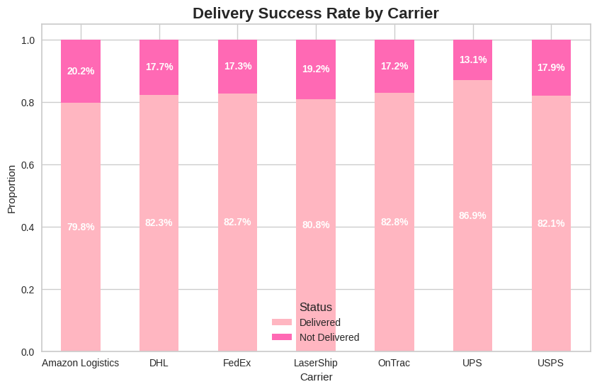

```python
# code for graph (stacked bar graph)
contingency_norm = contingency.div(contingency.sum(axis=1), axis=0)

colors = ['#FFB6C1', '#FF69B4']
ax = contingency_norm.plot(kind='bar', stacked=True, figsize=(10,6), color=colors)

for p in ax.patches:
    width, height = p.get_width(), p.get_height()
    x, y = p.get_xy()
    ax.text(x + width/2, y + height/2, f"{height*100:.1f}%", ha='center', va='center', fontsize=10, color='white', fontweight='bold')

plt.ylabel("Proportion")
plt.xlabel("Carrier")
plt.title("Delivery Success Rate by Carrier", fontsize=16, fontweight='bold')
plt.xticks(rotation=0)
plt.legend(title='Status', labels=['Delivered', 'Not Delivered'])

plt.show()
```

**Hypothesis 1 Conclusion**

Using a significance level of **alpha = 0.05**, our chi-square test of independence has resulted in a p-value of **p=0.52452**, so we **fail to reject** the null hypothesis. Additionally, there is a chi-square stat of **5**, which falls on the lower end indicating a smaller difference between observed data.

This means that there is no statistical evidence that delivery success rate depends on the carrier. In other words, all carriers appear to have similar delivery reliability in this dataset. This is evident in our graph above, where it seems that the bars are around the same level for each carrier.

Even though we have not found a significant difference between carriers in terms of success, we can further explore how different factors such as cost and seasons affect performance. This is shown in the next two hypothesis.

#### **Hypothesis 2:**

To further investigate if cost per shipment is related to transit efficiency, we use a pearson correlation and scatter plot to visualize and test if higher cost shipments move faster.

> Null (H0): Cost per shipment is unrelated to transit efficiency (distance per day).

> Alternative (HA): Higher-cost shipments are faster (higher transit distance per day).

```python
# code for pearson correlation
r, p = pearsonr(df['Cost'], df['Transit_Distance_per_Day'])
print(f"Pearson Correlation: {r:.3f}, p-value: {p}")
```

```
Pearson Correlation: 0.606, p-value: 1.059844600490084e-189
```

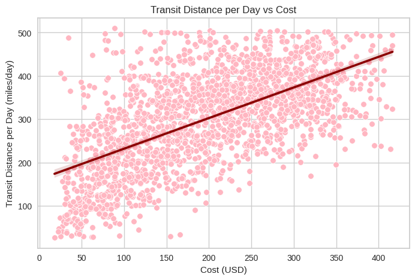

```python
# code for graph
plt.figure(figsize=(8,5))
sns.scatterplot(x='Cost', y='Transit_Distance_per_Day', data=df, color='#ffb6c1')
sns.regplot(x='Cost', y='Transit_Distance_per_Day', data=df, scatter=False, color='darkred')
plt.title("Transit Distance per Day vs Cost")
plt.xlabel("Cost (USD)")
plt.ylabel("Transit Distance per Day (miles/day)")
plt.show()
```

**Conclusion for Hypothesis 2:**

Using a significance level of **alpha = 0.05**, our pearson correlation test has resulted in a p-value of **p = 1.059844600490084e-189**, so we **reject** the null hypothesis.

This shows a strong positive relationship between shipment cost and transit efficiency. In other words, more expensive shipments tend to move faster, which aligns with the intuition that a faster delivery can be induced by paying more.

#### **Hypothesis 3:**

To investigate carrier performance, we analyze their performance across season and check over their transit efficiency. Since we compare many groups (carriers), we use a Two-way ANOVA test as well as Tukey Post-Hoc. Through the post-hoc, we get to look at localized differences between carrier and season.

> Null (H0): Carrier performance does not depend on the season (transit efficiency is consistent throughout the year).

> Alternative (HA): Carrier performance depends on the season.

```python
# code for two-way anova
model = ols('Transit_Distance_per_Day ~ C(Carrier) + C(Season) + C(Carrier):C(Season)', data=df).fit()
anova_table = sm.stats.anova_lm(model, typ=2)
print(anova_table)
```

```
                            sum_sq      df         F    PR(>F)
C(Carrier)            2.280385e+04     6.0  0.319337  0.927163
C(Season)             4.536119e+04     3.0  1.270446  0.282903
C(Carrier):C(Season)  1.979076e+05    18.0  0.923811  0.548959
Residual              2.213706e+07  1860.0       NaN       NaN
```

```python
# code for post-hoc
df['Carrier_Season'] = df['Carrier'] + '_' + df['Season']

tukey = pairwise_tukeyhsd(endog=df['Transit_Distance_per_Day'],
                          groups=df['Carrier_Season'],
                          alpha=0.05)
print(tukey)
```

```
                   Multiple Comparison of Means - Tukey HSD, FWER=0.05
=========================================================================================
         group1                  group2         meandiff p-adj    lower    upper   reject
-----------------------------------------------------------------------------------------
  Amazon Logistics_Fall Amazon Logistics_Spring  19.0746    1.0  -50.7914  88.9406  False
  Amazon Logistics_Fall Amazon Logistics_Summer  34.7891 0.9908  -35.8969  105.475  False
  Amazon Logistics_Fall Amazon Logistics_Winter -24.4477    1.0  -95.4221  46.5267  False
  Amazon Logistics_Fall                DHL_Fall  13.6421    1.0  -57.6288  84.9129  False
  Amazon Logistics_Fall              DHL_Spring  -6.3436    1.0  -75.9503  63.2632  False
  Amazon Logistics_Fall              DHL_Summer   8.5838    1.0  -58.9584   76.126  False
  Amazon Logistics_Fall              DHL_Winter  15.5148    1.0  -57.0302  88.0598  False
  Amazon Logistics_Fall              FedEx_Fall   3.5253    1.0  -64.8792  71.9297  False
  Amazon Logistics_Fall            FedEx_Spring  20.1524    1.0  -47.5978  87.9027  False
  Amazon Logistics_Fall            FedEx_Summer   8.0232    1.0  -60.6099  76.6564  False
  Amazon Logistics_Fall            FedEx_Winter   4.8524    1.0   -66.122  75.8268  False
  Amazon Logistics_Fall          LaserShip_Fall   3.0442    1.0  -65.3602  71.4487  False
  Amazon Logistics_Fall        LaserShip_Spring   7.4744    1.0  -60.4888  75.4376  False
  Amazon Logistics_Fall        LaserShip_Summer  -4.1965    1.0  -72.8296  64.4367  False
  Amazon Logistics_Fall        LaserShip_Winter  17.0379    1.0   -52.828  86.9039  False
  Amazon Logistics_Fall             OnTrac_Fall -15.4453    1.0  -84.3129  53.4222  False
  Amazon Logistics_Fall           OnTrac_Spring  -2.9801    1.0  -70.7304  64.7701  False
  Amazon Logistics_Fall           OnTrac_Summer  21.6099    1.0  -48.2561  91.4759  False
  Amazon Logistics_Fall           OnTrac_Winter  -8.1415    1.0   -77.009  60.7261  False
  Amazon Logistics_Fall                UPS_Fall    0.873    1.0   -69.813   71.559  False
  Amazon Logistics_Fall              UPS_Spring   7.3176    1.0  -65.2274  79.8626  False
  Amazon Logistics_Fall              UPS_Summer   3.4744    1.0  -67.7965  74.7453  False
  Amazon Logistics_Fall              UPS_Winter   2.1338    1.0   -72.235  76.5027  False
  Amazon Logistics_Fall               USPS_Fall   1.6625    1.0   -67.205    70.53  False
  Amazon Logistics_Fall             USPS_Spring    5.152    1.0  -67.3931   77.697  False
  Amazon Logistics_Fall             USPS_Summer  21.1747    1.0  -48.6913  91.0407  False
  Amazon Logistics_Fall             USPS_Winter   4.3904    1.0  -64.2428  73.0236  False
Amazon Logistics_Spring Amazon Logistics_Summer  15.7145    1.0  -55.2268  86.6558  False
Amazon Logistics_Spring Amazon Logistics_Winter -43.5223 0.8854 -114.7509  27.7064  False
Amazon Logistics_Spring                DHL_Fall  -5.4325    1.0  -76.9566  66.0916  False
Amazon Logistics_Spring              DHL_Spring -25.4181 0.9999  -95.2841  44.4479  False
Amazon Logistics_Spring              DHL_Summer -10.4908    1.0  -78.3001  57.3185  False
Amazon Logistics_Spring              DHL_Winter  -3.5598    1.0  -76.3536   69.234  False
Amazon Logistics_Spring              FedEx_Fall -15.5493    1.0  -84.2175   53.119  False
Amazon Logistics_Spring            FedEx_Spring   1.0779    1.0  -66.9387  69.0944  False
Amazon Logistics_Spring            FedEx_Summer -11.0513    1.0  -79.9474  57.8448  False
```

[output cut: 328 more lines]

```
             UPS_Summer               USPS_Fall  -1.8119    1.0   -72.361  68.7372  False
             UPS_Summer             USPS_Spring   1.6776    1.0  -72.4657  75.8208  False
             UPS_Summer             USPS_Summer  17.7003    1.0  -53.8238  89.2244  False
             UPS_Summer             USPS_Winter    0.916    1.0  -69.4043  71.2364  False
             UPS_Winter               USPS_Fall  -0.4713    1.0  -74.1488  73.2061  False
             UPS_Winter             USPS_Spring   3.0181    1.0  -74.1078  80.1441  False
             UPS_Winter             USPS_Summer  19.0409    1.0  -55.5707  93.6524  False
             UPS_Winter             USPS_Winter   2.2566    1.0  -71.2018   75.715  False
              USPS_Fall             USPS_Spring   3.4895    1.0  -68.3466  75.3255  False
              USPS_Fall             USPS_Summer  19.5122    1.0  -49.6173  88.6418  False
              USPS_Fall             USPS_Winter   2.7279    1.0  -65.1554  70.6113  False
            USPS_Spring             USPS_Summer  16.0227    1.0  -56.7711  88.8166  False
            USPS_Spring             USPS_Winter  -0.7615    1.0   -72.373  70.8499  False
            USPS_Summer             USPS_Winter -16.7843    1.0  -85.6804  52.1118  False
-----------------------------------------------------------------------------------------
```

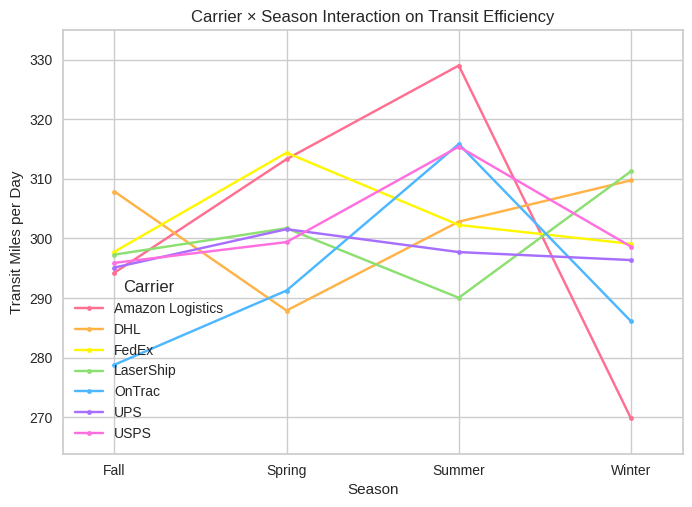

```python
# code for graph
from statsmodels.graphics.factorplots import interaction_plot
plt.figure(figsize=(10,6))
interaction_plot(df['Season'], df['Carrier'], df['Transit_Distance_per_Day'], colors=['#FF6F91', '#FFB347', '#FFF700', '#8CE071', '#4DB8FF', '#A76FFF', '#FF6FE0'])
plt.ylabel("Transit Miles per Day")
plt.title("Carrier × Season Interaction on Transit Efficiency")
plt.show()
```

**Conclusion for Hypothesis 3**

Using a significance level of **alpha = 0.05**, our two-way ANOVA test has resulted in p-values of **{Carrier: p = 0.927; Season: p = 0.283; Carrier x Season: p = 0.549}**, so we **fail to reject** the null hypothesis for all three categories.

This means that, statistically, there is no significant evidence that season affects transit efficiency across all carriers. However, visually looking at the graph we can notice that certain carriers, such as Amazon and OnTrac, tend to do much better in the summer than the winter, though the difference is neglible enough to not be statistically significant. Thought we failed to reject our null, the graph can still serve as a useful tool for noticing discrepancies across carrier performance based on season.

### **EDA Conclusion**

The `Exploratory Data Analysis` section of this report aimed to break down the U.S logistics performance and analyze the dataset and highlight any relationships and patterns that have the potential to derive useful insights that can contribue to logistics decisions and strategies that pertain to carrier instances.

## **Machine Learning Analysis and Visualization**

#### **Predicting Transit Days**

Based on the previous EDA conclusion, a strong positive relationship between the cost of shipment and its delivery speed was noted. Understanding how long a shipment will take provides important information to stakeholders that can help with logistical decisions and planning on both sides. Potentially saving time and money and increasing efficiency.

- **Carrier Selection:** Both customers and businesses are able to select carriers that are able to consistently fulfill the requirements of delivery speed for different shipment profiles (weight, distance, season, cost tier).
- **Operational Planning:** When companies are able to predict transit time more reliably, they can allocate warehouse staff, loading resources, and delivery windows in a more efficient way.
- **Pricing Strategy:** It is a common practice among carriers to charge more for faster deliveries. Predicting transit time gives businesses the opportunity to decide if the higher costs actually result in a significant saving of time.

Since transit speed has a direct influence on customer satisfaction and logistics costs, a predictive model for **Transit Days** is an excellent source of operational ‍‌‍‍‌‍‌‍‍‌insights.

**Feature Preparation and Train-Test Split**

We set Transit_Days as the target for prediction and use all other categories as model features.

```python
from sklearn.model_selection import train_test_split

# Target: Transit Days
y = df['Transit_Days']

# Use other factors as features
x = df.drop(["Shipment_ID", "Shipment_Date", "Delivery_Date", "Transit_Days"], axis = 1)

# 80 20 train - test
X_train, X_test, y_train, y_test = train_test_split(x, y, test_size=0.2, random_state=42)

# Encoding categorical variables
X_train = pd.get_dummies(X_train, drop_first = True) # Drop a variable to prevent redundance
X_test = pd.get_dummies(X_test, drop_first = True)

# Joining for alignment
X_train, X_test = X_train.align(X_test, join = 'left', axis = 1)
X_test = X_test.fillna(0)
```

### **Model Choice: Random Forest Regressor**

Random Forest Regression was chosen because it is appropriate for the structure of the dataset and the prediction task, especially due to the complexities of shipping logistics:

- **Handles nonlinear relationships:** Transit time is influenced by complex interactions (e.g., distance × weight, carrier × season), which linear models often fail to capture.
- **Naturally supports categorical features:** After one-hot encoding, Random Forests can meaningfully split on carrier, season, warehouse, and destination categories.
- **Resistant to outliers and noise:** Since the dataset intentionally includes outliers and realistic variation, Random Forest’s ensemble averaging reduces sensitivity to extreme values.
- **Feature importance insight:** Random Forests provide an interpretable ranking of the variables that most strongly influence transit days—valuable for business decision-making.

```python
from sklearn.ensemble import RandomForestRegressor

# Create the random forest regressor
rf = RandomForestRegressor(
    n_estimators = 300,
    random_state = 42,
    n_jobs = -1
)

# fit the model with the data
rf.fit(X_train, y_train)
```

```
RandomForestRegressor(n_estimators=300, n_jobs=-1, random_state=42)
```

#### **Model Evaluation**

We evaluate the model using common regression metrics:

- R^2 Score (Coefficient of Determination)- How much variance in the target is explained by the model
- MAE (Mean Absolute Error) - How many units the model's prediction is off by
- RMSE (Root Mean Squared Error) - Square root of mean^2 errors, how big any errors are

```python
# Mean Absolute Error (Average Misses) and Mean Squared Error to detect how accurate model is predicting transit time
from sklearn.metrics import mean_absolute_error, mean_squared_error, r2_score

predictions = rf.predict(X_test)

# Calculate each regression metric
mae = mean_absolute_error(y_test, predictions)
mse = (mean_squared_error(y_test, predictions))
rmse = np.sqrt(mse)
r2 = r2_score(y_test, predictions)

print("R2 Score:", r2)
print("Mean Absolute Error:", mae)
print("Mean Squared Error:", mse)
print("Root Mean Squared Error:", rmse)
```

```
R2 Score: 0.9908273722655023
Mean Absolute Error: 0.07140211640211638
Mean Squared Error: 0.03434606114050559
Root Mean Squared Error: 0.18532690344498176
```

#### **Model Performance Interpretation**

- **R^2 score: 0.991** The model explains approximately 99.1% of the variation in transit days. This indicates an extremely strong fit and suggests that the features in the dataset provide substantial predictive power for estimating delivery time.
- **MAE: 0.071 days (1.7 hours)** On average, the model’s predictions are extremely close to the actual transit duration.
- **RMSE: 0.185 days (4.4 hours)** This confirms that even larger prediction errors are rare and remain within a practically acceptable window for logistics operations.

From a business perspective, this level of accuracy is highly valuable. A model that can consistently predict transit duration within a few hours can allow organizations to:

- Improve delivery scheduling and warehouse staffing
- Set more accurate customer delivery expectations
- Estimate whether higher shipping costs meaningfully reduce transit time
- Compare carrier performance under equivalent shipment conditions

Overall, the model performs well and provides reliable predictions that can be applied to real-world logistics planning.

### **Feature Importance Analysis**

```python
important_features = pd.DataFrame(rf.feature_importances_, index = X_train.columns)
important_features.sort_values(by = 0, ascending = False).head(20)
```

|  | 0 |
| --- | --- |
| Distance_miles | 0.668724 |
| Transit_Distance_per_Day | 0.311351 |
| Cost | 0.011805 |
| Weight_kg | 0.001865 |
| Status_Not Delivered | 0.000408 |
| Origin_Warehouse_Warehouse_BOS | 0.000396 |
| Carrier_OnTrac | 0.000282 |
| Season_Summer | 0.000212 |
| Origin_Warehouse_Warehouse_MIA | 0.000207 |
| Carrier_Season_UPS_Spring | 0.000166 |
| Carrier_Season_Amazon Logistics_Winter | 0.000166 |
| Season_Spring | 0.000159 |
| Destination_San Francisco | 0.000148 |
| Destination_Los Angeles | 0.000147 |
| Carrier_FedEx | 0.000144 |
| Carrier_USPS | 0.000134 |
| Destination_Phoenix | 0.000134 |
| Season_Winter | 0.000130 |
| Origin_Warehouse_Warehouse_DEN | 0.000123 |
| Origin_Warehouse_Warehouse_SEA | 0.000117 |

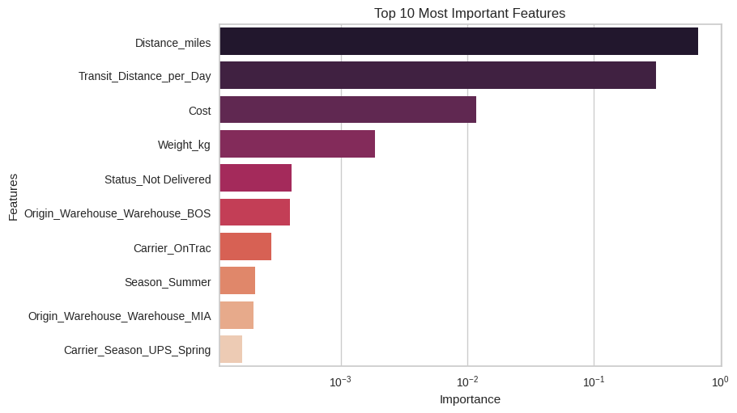

```python
# Sort and display features by importance in a bar graph
top_features = important_features.sort_values(by = 0, ascending = False).head(10)
plt.figure()
sns.barplot(
    x = top_features.iloc[:,0].values,
    y = top_features.index,
    palette = "rocket", hue = top_features.index
)
plt.xscale("log")
plt.title("Top 10 Most Important Features")
plt.xlabel("Importance")
plt.ylabel("Features")
```

Given the plot above, the feature with the most contribution for transit time is **distance_miles**.

With expectations that the length of transit is dependent on the distance to the destination confirmed, we can look at other factors to take into consideration when moving forward with data-backed decision making.

Although the scaled importance factor shows very small values for factors like cost, weight, season, etc- this may help in establishing solutions that deduct transit time for more efficient and speedy delivery.

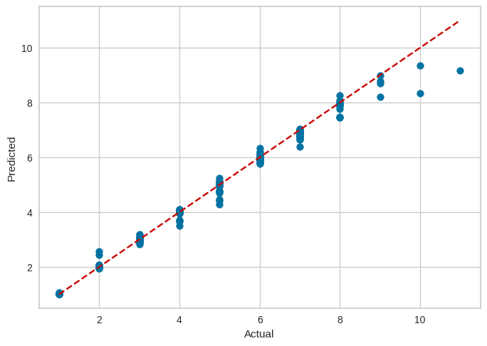

```python
# Predicted vs. Actual Plot
plt.figure()
plt.scatter(y_test, predictions)
plt.plot([y_test.min(), y_test.max()], [y_test.min(), y_test.max()],  "r--")
plt.xlabel("Actual")
plt.ylabel("Predicted")
```

By the diagonal reference line indicating accuracy when comparing predicted and actual values, we can see that the model provides a strong performance through the clustered values along the diagonal line. This suggests that the model generally predicts transit time well with a few deviations in higher values.

## **Clustering**

Clustering will help us identify natural shipment groups based on performance-related metrics. After running hypothesis tests and building predictive models, clustering provides a way to detect patterns in shipping behaviors and understand natural operational groups.

Similar to HW4, the process involves:

- **One-Hot encoding** for categorical features
- **StandardScaler** to scale features to prepare for clustering
- **KMeans** to apply Elbow Method, identifying when adding clusters doesn't help variance anymore.
- **Within-Cluster sum of squares**: minimize Intertia as described in Section 2.3.2 of Kmeans

> https://scikit-learn.org/stable/modules/clustering.html

#### **Feature Engineering**

To ensure meaningful clusters, we create features specifically tied to cost and performance. This improves interpretability and avoids poorly separated clusters.

```python
df = df.copy()

# Performance-focused features
df['Cost_per_mile'] = df['Cost'] / df['Distance_miles']
df['Transit_Distance_per_Day'] = df['Distance_miles'] / df['Transit_Days']

# Distance bins for "peer group"
df['distance_bin'] = pd.qcut(df['Distance_miles'], q=5, duplicates='drop')

# Median transit days per bin and deviation from that median
median_by_bin = (
    df.groupby('distance_bin', observed=True)['Transit_Days']
      .transform('median')
)
df.loc[:, 'Transit_Days_above_median'] = df['Transit_Days'] - median_by_bin

# Chosen feature set
cluster_features = ['Cost_per_mile',
                    'Transit_Distance_per_Day',
                    'Transit_Days_above_median']

cluster_df = df[cluster_features].copy()
```

#### **Clustering Method:**

1. Scaling Features - since KMeans is distance based, it is important to scale features.
2. Elbow method - we adapt the HW4 distortion score to compute mean distortion per point.

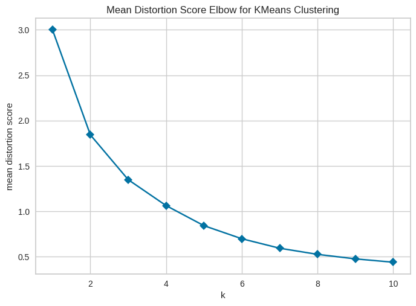

```python
from sklearn.preprocessing import StandardScaler
from sklearn.cluster import KMeans
from yellowbrick.cluster import KElbowVisualizer
import yellowbrick.cluster.elbow as elbow_module
from yellowbrick.cluster.elbow import distortion_score

scaler = StandardScaler()
df_scaled_array = scaler.fit_transform(cluster_df)
df_scaled = pd.DataFrame(df_scaled_array, columns=cluster_features, index=cluster_df.index)

#Formatting off of HW4
def mean_distortion_score(X, labels, metric="euclidean"):
    """Compute the mean distortion (average squared distance to centroids)"""
    total_distortion = distortion_score(X, labels, metric)
    return total_distortion / X.shape[0]

elbow_module.KELBOW_SCOREMAP['distortion'] = mean_distortion_score

model = KMeans(random_state=42, n_init=10)

#Instantiate the KElbowVisualizer with the model and k range
visualizer = KElbowVisualizer(model, k=(1,11), metric='distortion', timings=False, locate_elbow=False)
visualizer.fit(df_scaled)
visualizer.show()
```

#### **Silhouette Score Analysis**

We use the silhouette score to accompany elbow method. The silhouette score measures similarity between and object and it's cluster compared to other clusters.

Main characteristics:

- Higher scores indicate better-defined clusters.
- Requires AT LEAST 2 clusters (range must start at 2)

> Yellowbrick documentation here: https://www.scikit-yb.org/en/latest/api/cluster/silhouette.html

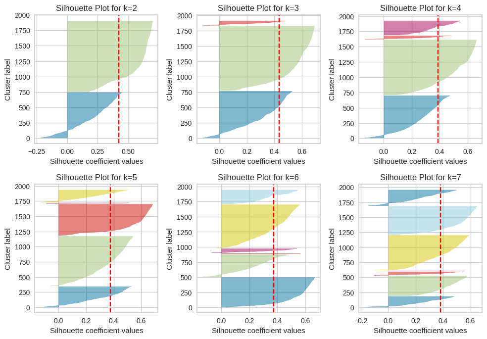

```python
from yellowbrick.cluster import SilhouetteVisualizer

# Choose a range of k values to evaluate
range_n_clusters = range(2, 8) # Silhouette score requires at least 2 clusters

plt.figure(figsize=(10, 10))

for i, k in enumerate(range_n_clusters):
    ax = plt.subplot(3, 3, i + 1) # Arrange plots in a grid

    # Instantiate the clustering model with a random state of 42 for reproducibility
    model = KMeans(n_clusters=k, init='k-means++', random_state=42, n_init=10)

    # Create a SilhouetteVisualizer instance with the KMeans model
    visualizer = SilhouetteVisualizer(model, colors='yellowbrick', ax=ax)

    # Fit to data and set titles
    visualizer.fit(df_scaled)
    ax.set_title(f'Silhouette Plot for k={k}')
    ax.set_xlabel('Silhouette coefficient values')
    ax.set_ylabel('Cluster label')

plt.tight_layout()
plt.show()
```

**K Decision:** Both the elbow curve and the silhouette plots support **k = 3** as a balanced option. The graph for **k = 3** has the highest average silhouette score, and the clusters are wide and without many negative values, generally well-defined.

#### **Final Clustering with K=3**

```python
optimal_k = 3 # Chosen from on Elbow Method and Silhouette Score

kmeans = KMeans(n_clusters=optimal_k, init='k-means++', random_state=42, n_init=10)
df['Cluster'] = kmeans.fit_predict(df_scaled)

summary_features = cluster_features
cluster_summary = df.groupby('Cluster')[summary_features].mean()

print("Cluster Summary (Mean Performance Features):\n", cluster_summary)
```

```
Cluster Summary (Mean Performance Features):
          Cost_per_mile  Transit_Distance_per_Day  Transit_Days_above_median
Cluster
0             0.173379                212.426607                   1.230971
1             0.155065                375.814159                  -0.531369
2             0.462800                121.810135                   0.081081
```

#### **Clustering Visualization**

The summary may be hard to read and understand, let's plot it!

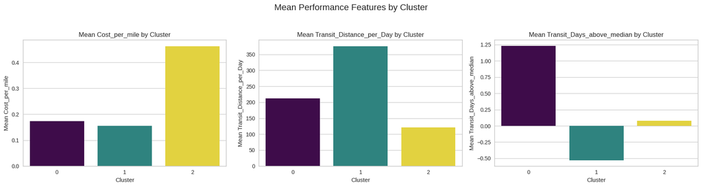

```python
fig, axes = plt.subplots(nrows=1, ncols=3, figsize=(18, 5))
fig.suptitle('Mean Performance Features by Cluster', fontsize=16)

plot_features = cluster_features

for ax, feature in zip(axes, plot_features):
    sns.barplot(
        x=cluster_summary.index,
        y=cluster_summary[feature],
        ax=ax,
        palette='viridis',
        hue=cluster_summary.index,
        legend=False
    )
    ax.set_title(f'Mean {feature} by Cluster')
    ax.set_xlabel('Cluster')
    ax.set_ylabel(f'Mean {feature}')

plt.tight_layout(rect=[0, 0.03, 1, 0.95])
plt.show()
```

#### **Cluster Interpretation**

These clusters help us with discerning characteristics from each group:

**Cluster 0**

- Most notable feature is the high Mean Transit_Days_above_median, implying that shipments in this cluster are slower than expected, with average cost and efficiency.

**Cluster 1**

- This cluster houses the best performers, as we see that it has the lowest cost, highest distance, and negative Transit_Days_above_median. The negative bar plot may seem alarming, but this just shows that shipments may come earlier than expected.

**Cluster 2**

- This cluster seems to be the worst performer, as it is the most expensive yet slowest per day. The slightly positive Days_above_median may suggest they are only slightly slower than expected, but not as efficient as cluster 1.

With further separation, we can isolate these characteristics based on carriers, seasons, or other main factors to evaluate logistics operations.

## **Insights and Conclusion**

This‍‌‍‍‌‍‌‍‍‌ project focused on U.S. logistics performance by using statistical analysis and machine learning to discover how factors like carrier choice, shipment cost, distance, and seasonal timing impact delivery outcomes. By combining hypothesis testing, exploratory analysis, and predictive modeling, we discovered key drivers of transit efficiency.

### **Practical Recommendations for Shippers**

One of the major insights that came from our data serve as actionable guidelines for businesses and individuals in charge of shipment planning:

- **Distance Is the Primary Driver of Transit Time**

Our Random Forest model confirmed that distance is the main factor that delivery duration depends on. Shippers are advised to prioritize warehouses or distribution centers that are geographically closest to them.

- **Paying More Generally Improves Delivery Speed**

Both Pearson correlation and cost-related feature importance show that fast delivery is associated with high-cost shipments. In this case, if the need for the shortest delivery is pressing, then a premium shipping tier or higher-priced services should be chosen.

- **Carrier Reliability Is Statistically Similar**

The chi-square test indicates that delivery achievement rates are more or less the same across carriers. What this means is, at least in this dataset, carrier choice hardly causes shipment delivery success variation. Therefore, carrier choice can be based on other factors such as cost.

### **Carrier Insights**

**Cost–Efficiency Tradeoff**

Although overall reliability is similar, we can see from the model that there are minor differences in speed that can change with seasons and vary from one carrier to another. Some carriers may regularly be able to run faster on certain routes or during specific times of the year; that the main reason behind the price increase is the downtick in the efficiency of the operations, optimization of the route, or priority handling; companies that are always shipping large volumes of products can get the most out of performance measurement at carrier-level through their shipment history by benchmarking.

### **Limitations of the Dataset**

The dataset was sufficient to allow for a completed analysis. However, we should still take into account the limitations of the dataset:

- **Simulated Data**

The dataset is completely fictional in terms of noise, outliers, and patterns, as it is not a real-world collection. Actual shipping behavior might be enveloped with additional complexities like weather disruptions, strikes, traffic conditions, or route-level constraints.

- **Limited Operational Variables**

Some of the most critical logistics features, such as the mode of transport (air, ground), the number of transfer points, and the size of the package, are not accounted for. These factors could significantly affect delivery times.

- **Limited Time Span**

The enhancement of shipment dates with multi-year data could facilitate the in-depth research of long-term seasonal trends or pandemic-level disruptions.

- **Uniform Carrier Behavior**

The differences could be quite small between the performance of the actual shipping companies due to the balanced performance across carriers simulated in the dataset.

These drawbacks must be taken into consideration when using our findings in real logistics situations.

### **Future Work**

This mission has several second thoughts in it, which could later be extended farther:

- **Modeling Delivery Failures**

A classification model capable of identifying failed or delayed shipments would be an important source of practical information that could lead to risk reduction and higher customer satisfaction.

- **Clustering Shipment Patterns**

Unsupervised learning (e.g., K-means or hierarchical clustering) may uncover hidden shipment archetypes, such as priority freight, regional routes, or weight-based categories, that determine delivery speed.

- **Time-Series Modeling**

Time-series models (ARIMA, Prophet) application on a multi-year richer dataset may bring out seasonal cycles, holiday spikes, and long-term efficiency changes.

- **Route-Level Optimization Studies**

The linkage of transit times with route geographies, weather APIs, or transportation network data may result in advanced logistics optimization.